# 音频数字化课堂活动单

姓名：________ 班级：________

## Q3 怎样留下波形随时间的变化？

这一秒的曲线怎样记录？

在纸上圈出你准备读取的时刻。

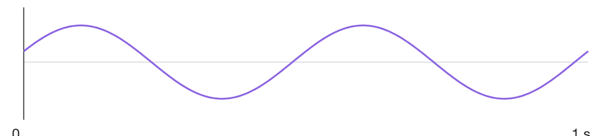

我的记录／算式：

我的解释：____________________________

## Q5 样本值不在可选等级上，怎么办？

四个样本：−0.62、−0.10、0.38、0.84。

只能用：−0.75、−0.25、0.25、0.75近似。

分别选哪个？

| 样本值 | 我的近似值 | Q6码字：学到编码后再填 |
| --- | --- | --- |
| −0.62 | ________ | ________ |
| −0.10 | ________ | ________ |
| 0.38 | ________ | ________ |
| 0.84 | ________ | ________ |

同桌互读码字，查回的是原样本值，还是近似值？________

我的记录／算式：

我的解释：____________________________

## Q6 四个量化等级，怎样写成码字？

从低到高编号0、1、2、3；采用等长二进制码。

每个样本至少几bit？写出四个码字。

填写上一表的码字栏，再向同桌读回代表值。

我的记录／算式：

我的解释：____________________________

## Q7 只有码字，就能按原速播放吗？（课后拓展，课堂不填）

单声道：00 01 10 11；同一张四等级码表。

共4个样本，能确定这段声音的时长吗？

我的记录／算式：

我的解释：____________________________

## Q16 一分钟双声道PCM有多大？

44.1kHz、16bit、双声道，录音1分钟。

求样本数据量（B）；换算MiB列式即可。

1 MiB = 1,048,576 B。

采样率：________Hz；时长：________s；存储位数：________bit；声道数：________。

我的记录／算式：

我的解释：____________________________

## Q18 只有64KiB，哪种方案满足要求？

带限信号最高频率6kHz；记录2秒。

16bit、单声道；上限64KiB = 65,536B（仅样本数据）。

候选采样率：8k、16k、24kHz。逐项检查两个条件。

靠窗同学先查8kHz，另一位先查24kHz，再共同查16kHz；每个方案都检查两项条件。

| 候选采样率 | 频率条件是否满足，为什么 | 样本数据量B | 容量是否满足 |
| --- | --- | --- | --- |
| 8kHz | ________ | ________ | ________ |
| 16kHz | ________ | ________ | ________ |
| 24kHz | ________ | ________ | ________ |

我的记录／算式：

我的解释：____________________________

## Q19 哪些说法需要修改？

① 8kHz采样，声音自身频率就是8kHz。

② 16bit量化只有16个等级。

③ 所有WAV都未压缩，公式算出完整文件大小。

我的记录／算式：

我的解释：____________________________